# Notebook

**Einführung in Vektoren und NumPy**

Dr. Matthias Hölzl

## Warum NumPy?

Erinnern Sie sich an unsere Berechnungen:

- Viele Multiplikationen und Additionen
- Schleifen über Listen
- Fehleranfällig und langsam bei vielen Daten

Unser bisheriger Ansatz

```python
features = [120, 3, 2, 10, 1]
coefficients = [0.3, 20.0, 15.0, -2.0, 25.0]
```

Manuelle Berechnung

```python
result = 0
for f, c in zip(features, coefficients):
    result += f * c
```

```python
result
```

```
131.0
```

## NumPy: Numerical Python

- Bibliothek für numerische Berechnungen
- Macht Mathematik mit vielen Zahlen einfach
- Viel schneller als normale Python-Listen
- Standard in Data Science und Machine Learning

## NumPy installieren und importieren

NumPy ist normalerweise in Data Science Umgebungen vorinstalliert. Falls nicht:

```python
!pip install numpy --root-user-action=ignore
```

```python
import numpy as np  # 'np' is the standard abbreviation
```

NumPy Version:

```python
np.__version__
```

```
'2.3.3'
```

## Ihr erstes NumPy Array

- Ein Array ist wie eine Liste, aber optimiert für Mathematik
- Kann aus Listen erstellt werden
- Unterstützt viele mathematische Operationen direkt

```python
my_list = [1, 2, 3, 4, 5]
```

```python
my_array = np.array(my_list)
```

```python
my_array = np.array([1, 2, 3, 4, 5])
```

```python
my_list
```

```
[1, 2, 3, 4, 5]
```

```python
my_array
```

```
array([1, 2, 3, 4, 5])
```

```python
type(my_list)
```

```
list
```

```python
type(my_array)
```

```
numpy.ndarray
```

## Arrays inspizieren

```python
arr = np.array([10, 20, 30, 40, 50])
```

```python
arr
```

```
array([10, 20, 30, 40, 50])
```

```python
len(arr)
```

```
5
```

```python
arr.shape  # Dimensions of the array
```

```
(5,)
```

```python
arr.size  # Total number of elements
```

```
5
```

```python
arr.dtype  # Type of elements
```

```
dtype('int64')
```

## Auf Elemente zugreifen

```python
arr = np.array([10, 20, 30, 40, 50])
```

Genau wie Listen!

```python
arr[0]
```

```
np.int64(10)
```

```python
arr[-1]
```

```
np.int64(50)
```

```python
arr[1:4]
```

```
array([20, 30, 40])
```

Aber Vorsicht - Arrays haben einen festen Typ

```python
arr[0] = 15.5  # Float wird zu Int konvertiert
```

```python
arr
```

```
array([15, 20, 30, 40, 50])
```

```python
arr.dtype  # Noch immer Integer
```

```
dtype('int64')
```

## Vektoren: Listen mit Superkräften

In der Mathematik ist ein Vektor eine geordnete Liste von Zahlen:

- Kann Koordinaten im Raum darstellen
- Kann Features eines Datenpunkts darstellen
- Kann mit anderen Vektoren verrechnet werden

## Vektoren visualisieren (2D)

```python
import matplotlib.pyplot as plt
from plot_utils import plot_2d_vector, plot_vector_addition
```

Ein 2D-Vektor als Koordinaten

```python
vector_2d = np.array([3, 2])
```

Visualisiere als Pfeil vom Ursprung

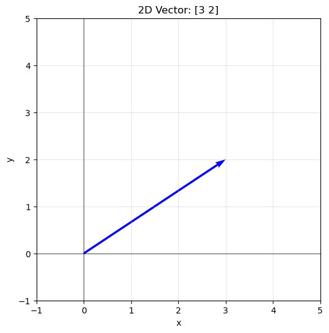

```python
plot_2d_vector(vector_2d)
```

## Vektoren als Feature-Sammlungen

In ML repräsentieren Vektoren oft Features:

- Haus-Features als Vektor

```python
house_vector = np.array([120, 3, 2, 10, 1])  # size, bedrooms, bathrooms, age, garage
```

```python
house_vector
```

```
array([120,   3,   2,  10,   1])
```

```python
len(house_vector)
```

```
5
```

- Jede Position hat eine Bedeutung

```python
feature_names = ["size_sqm", "bedrooms", "bathrooms", "age_years", "garage"]
```

```python
for i, (name, value) in enumerate(zip(feature_names, house_vector)):
    print(f"Position {i}: {name} = {value}")
```

```
Position 0: size_sqm = 120
Position 1: bedrooms = 3
Position 2: bathrooms = 2
Position 3: age_years = 10
Position 4: garage = 1
```

## Einfache Array-Operationen

NumPy macht Mathematik mit Arrays einfach:

## Skalare Operationen

Operationen mit einzelnen Zahlen:

```python
prices = np.array([100, 200, 150, 300, 250])
```

```python
prices
```

```
array([100, 200, 150, 300, 250])
```

50 zu allen Preisen addieren

```python
increased = prices + 50
```

```python
increased
```

```
array([150, 250, 200, 350, 300])
```

10% Rabatt auf alle Preise

```python
discounted = prices * 0.9
```

```python
discounted
```

```
array([ 90., 180., 135., 270., 225.])
```

## Vergleich: Listen vs. Arrays

- Listen unterstützen keine direkten mathematischen Operationen
  - Benötigen Schleifen oder List Comprehensions
- NumPy Arrays unterstützen elementweise Operationen direkt

```python
list_prices = [100, 200, 150, 300, 250]
```

```python
array_prices = np.array([100, 200, 150, 300, 250])
```

Mit Listen - Comprehension ist nötig

```python
list_discounted = [price  * 0.9 for price in list_prices]
```

```python
list_discounted
```

```
[90.0, 180.0, 135.0, 270.0, 225.0]
```

Mit Arrays - einfach multiplizieren!

```python
array_discounted = array_prices * 0.9
```

```python
array_discounted
```

```
array([ 90., 180., 135., 270., 225.])
```

### Vorsicht: Listen und Multiplikation

- Man kann auch Listen mit ganzen Zahlen multiplizieren
- Das bedeutet etwas ganz anderes als in der Mathematik!

```python
[1, 2, 3] * 3  # List replication, not element-wise multiplication
```

```
[1, 2, 3, 1, 2, 3, 1, 2, 3]
```

```python
np.array([1, 2, 3]) * 3  # Element-wise multiplication
```

```
array([3, 6, 9])
```

## Vektoraddition

- Wir können Vektoren addieren
- Addition erfolgt **elementweise**
- Die Vektoren müssen die gleiche Länge haben

### Beispiel

- Monatliche Verkäufe für zwei Produkte
- Die Summe ist der Gesamtverkauf pro Monat

```python
product_a = np.array([100, 120, 90, 110, 105])
product_b = np.array([80, 85, 95, 90, 88])
```

```python
product_a
```

```
array([100, 120,  90, 110, 105])
```

```python
product_b
```

```
array([80, 85, 95, 90, 88])
```

Gesamtverkäufe pro Monat

```python
total_sales = product_a + product_b
```

```python
total_sales
```

```
array([180, 205, 185, 200, 193])
```

## Visualisierung der Vektoraddition (2D)

```python
v1 = np.array([3, 1])
v2 = np.array([1, 2])
```

```python
v_sum = v1 + v2
```

Zeichne Vektoren

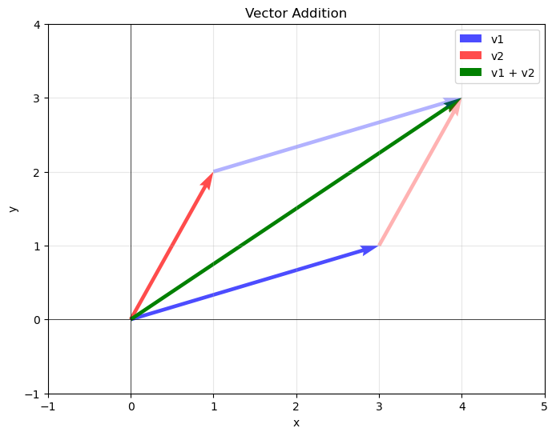

```python
plot_vector_addition(v1, v2)
```

## Methoden auf Vektoren

- NumPy bietet eine Vielzahl von Methoden für Vektoren
- Häufig verwendete Methoden sind:
  - `np.sum()` für die Summe aller Elemente
  - `np.mean()` für den Durchschnitt
  - `np.max()` und `np.min()` für Maximum und Minimum
  - `np.argmax()` und `np.argmin()` für die Indizes von Max/Min

```python
data = np.array([25, 10, 30, 50, 45])
```

Summe aller Elemente

```python
data.sum()
```

```
np.int64(160)
```

Durchschnitt der Elemente

```python
data.mean()
```

```
np.float64(32.0)
```

```python
data.sum() / len(data)
```

```
np.float64(32.0)
```

```python
data.sum() / data.size
```

```
np.float64(32.0)
```

Maximum und Minimum der Elemente

```python
data.max()
```

```
np.int64(50)
```

```python
data.min()
```

```
np.int64(10)
```

Index des Maximums

```python
data.argmax()
```

```
np.int64(3)
```

Index des Minimums

```python
data.argmin()
```

```
np.int64(1)
```

## Logische Operationen auf Vektoren

- Logische Operationen können **elementweise** auf NumPy Arrays angewendet werden.
- Gängige Operationen sind:
  - Größer als (`>`)
  - Kleiner als (`<`)
  - Gleich (`==`)
  - Logisches UND (`&`)
  - Logisches ODER (`|`)

```python
data = np.array([10, 25, 30, 45, 50])
```

Ist der jeweilige Wert größer als 30?

```python
data > 30
```

```
array([False, False, False,  True,  True])
```

```python
big_value_mask = data > 30
```

```python
big_value_mask
```

```
array([False, False, False,  True,  True])
```

Ist der jeweilige Wert gleich 25?

```python
data == 25
```

```
array([False,  True, False, False, False])
```

```python
equal_25_mask = data == 25
```

```python
equal_25_mask | big_value_mask  # Werte > 30 oder == 25
```

```
array([False,  True, False,  True,  True])
```

## Fancy Indexing

- Boolesche Arrays können als Indizes verwendet werden, um Elemente auszuwählen
- Das Ergebnis enthält nur die Elemente, bei denen der Index `True` ist
- Nützlich für Filterung und bedingte Auswahl

```python
data = np.array([10, 25, 30, 45, 50])
data
```

```
array([10, 25, 30, 45, 50])
```

```python
mask = data > 30
mask
```

```
array([False, False, False,  True,  True])
```

Werte größer als 30

```python
data[mask]
```

```
array([45, 50])
```

```python
data[data > 30]  # Direktes Filtern ohne Zwischenspeicherung
```

```
array([45, 50])
```

```python
data
```

```
array([10, 25, 30, 45, 50])
```

```python
data % 15
```

```
array([10, 10,  0,  0,  5])
```

```python
data % 15 == 0
```

```
array([False, False,  True,  True, False])
```

```python
data[data % 15 == 0]  # Werte, die durch 15 teilbar sind
```

```
array([30, 45])
```

## Zusammenfassung

- NumPy Arrays sind optimierte Listen für numerische Berechnungen
- Vektoren sind geordnete Zahlensammlungen
- Arrays ermöglichen Operationen ohne Schleifen
- Elementweise Operationen sind einfach und schnell
- Perfekt für ML-Features und Koeffizienten!

## Nächste Schritte

- Wir können Features und Koeffizienten als Vektoren darstellen
- Aber wie berechnen wir effizient Vorhersagen?
- Nächstes Thema: Das Skalarprodukt (Dot Product)
- Die wichtigste Operation in linearer Regression!

## Workshop: NumPy Grundlagen

Üben wir den Umgang mit NumPy Arrays!

### Aufgabe 1: Arrays erstellen

Erstellen Sie NumPy Arrays für:

1. Die Temperaturen einer Woche: [18, 20, 22, 19, 21, 23, 20]
2. Die Preise von 5 Produkten: [9.99, 14.50, 7.25, 22.00, 18.75]
1. Wochentemperaturen

```python
temperatures = np.array([18, 20, 22, 19, 21, 23, 20])
```

```python
print(f"Temperatures: {temperatures}")
print(f"Shape: {temperatures.shape}")
print(f"Average temperature: {temperatures.mean():.1f}°C")
```

```
Temperatures: [18 20 22 19 21 23 20]
Shape: (7,)
Average temperature: 20.4°C
```

2. Produktpreise

```python
prices = np.array([9.99, 14.50, 7.25, 22.00, 18.75])
```

```python
print(f"Prices: {prices}")
print(f"Total price: ${prices.sum():.2f}")
```

```
Prices: [ 9.99 14.5   7.25 22.   18.75]
Total price: $72.49
```

### Aufgabe 2: Array-Operationen

Mit den Temperatur-Daten:

1. Konvertieren Sie alle Temperaturen von Celsius zu Fahrenheit (F = C × 1.8 + 32)
2. Erzeugen Sie einen Vektor, der alle Celsius-Werte über 20°C enthält
3. Erzeugen Sie einen Vektor, der alle Celsius-Werte für Tage mit über 70°F enthält

```python
temperatures = np.array([18, 20, 22, 19, 21, 23, 20])
```

1. Nach Fahrenheit konvertieren

```python
fahrenheit = temperatures * 1.8 + 32
```

```python
print("Celsius to Fahrenheit conversion:")
for c, f in zip(temperatures, fahrenheit):
    print(f"{c}°C = {f:.1f}°F")
```

```
Celsius to Fahrenheit conversion:
18°C = 64.4°F
20°C = 68.0°F
22°C = 71.6°F
19°C = 66.2°F
21°C = 69.8°F
23°C = 73.4°F
20°C = 68.0°F
```

2. Tage über 20°C

```python
warm_days = temperatures > 20
```

```python
print(f"\nTemperatures:    {temperatures}")
print(f"Above 20°C Mask: {warm_days}")
print(f"Above 20°C:      {temperatures[warm_days]}")
```

```
Temperatures:    [18 20 22 19 21 23 20]
Above 20°C Mask: [False False  True False  True  True False]
Above 20°C:      [22 21 23]
```

```python
fahrenheit_above_70 = (temperatures * 1.8 + 32) > 70
print(f"Above 70°F Mask: {fahrenheit_above_70}")
print(f"Above 70°F:      {temperatures[fahrenheit_above_70]}")
```

```
Above 70°F Mask: [False False  True False False  True False]
Above 70°F:      [22 23]
```

### Aufgabe 3: Vektoroperationen

Ein Geschäft verkauft 3 Produkte über 4 Wochen:

```python
# Sales data (units sold per week)
week1 = np.array([10, 15, 8])
week2 = np.array([12, 14, 10])
week3 = np.array([8, 16, 12])
week4 = np.array([15, 13, 9])

# Prices per unit
prices = np.array([25.0, 40.0, 15.0])
```

Berechnen Sie:

1. Gesamtverkäufe pro Produkt über alle Wochen
2. Umsatz pro Woche
1. Gesamtverkäufe pro Produkt

```python
total_per_product = week1 + week2 + week3 + week4
```

```python
print("Total sales per product:")
product_names = ["Product A", "Product B", "Product C"]
for name, total in zip(product_names, total_per_product):
    print(f"{name}: {total} units")
```

```
Total sales per product:
Product A: 45 units
Product B: 58 units
Product C: 39 units
```

2. Umsatz pro Woche

```python
revenue_week1 = week1 * prices
revenue_week2 = week2 * prices
revenue_week3 = week3 * prices
revenue_week4 = week4 * prices
```

```python
print("\nRevenue per week:")
print(f"Week 1: ${revenue_week1.sum():.2f}")
print(f"Week 2: ${revenue_week2.sum():.2f}")
print(f"Week 3: ${revenue_week3.sum():.2f}")
print(f"Week 4: ${revenue_week4.sum():.2f}")
```

```
Revenue per week:
Week 1: $970.00
Week 2: $1010.00
Week 3: $1020.00
Week 4: $1030.00
```

```python
total_revenue = (revenue_week1 + revenue_week2 + revenue_week3 + revenue_week4).sum()
print(f"\nTotal revenue: ${total_revenue:.2f}")
```

```
Total revenue: $4030.00
```

### Aufgabe 4: Feature-Vektoren

Erstellen Sie Feature-Vektoren für 3 Wohnungen und berechnen Sie eine Bewertung mit gegebenen Gewichten.

|  | Größe (qm) | Schlafzimmer | Etage | Balkon |
| --- | --- | --- | --- | --- |
| Wohnung 1 | 65 | 2 | 3 | Ja (1) |
| Wohnung 2 | 85 | 3 | 1 | Nein (0) |
| Wohnung 3 | 55 | 1 | 5 | Ja (1) |

Die Gewichte sind:

| Feature | Gewicht |
| --- | --- |
| Größe | 2.0 |
| Schlafzimmer | 20.0 |
| Etage | 5.0 |
| Balkon | 15.0 |

```python
apt1 = np.array([65, 2, 3, 1])
apt2 = np.array([85, 3, 1, 0])
apt3 = np.array([55, 1, 5, 1])
```

```python
print("Apartments:")
print(f"Apt 1: {apt1}")
print(f"Apt 2: {apt2}")
print(f"Apt 3: {apt3}")
```

```
Apartments:
Apt 1: [65  2  3  1]
Apt 2: [85  3  1  0]
Apt 3: [55  1  5  1]
```

```python
weights = np.array([2.0, 20.0, 5.0, 15.0])
```

```python
print(f"\nWeights: {weights}")
```

```
Weights: [ 2. 20.  5. 15.]
```

Berechnen Sie die Bewertung für jede Wohnung (ohne Schleifen für die Berechnung der einzelnen Bewertungen!).

```python
score1 = (apt1 * weights).sum()
score2 = (apt2 * weights).sum()
score3 = (apt3 * weights).sum()
```

```python
print("Apartment Scores:")
print(f"Apartment 1: {score1:.1f} points")
print(f"Apartment 2: {score2:.1f} points")
print(f"Apartment 3: {score3:.1f} points")
```

```
Apartment Scores:
Apartment 1: 200.0 points
Apartment 2: 235.0 points
Apartment 3: 170.0 points
```

Finden Sie die beste Wohnung (die mit der höchsten Bewertung).

```python
scores = np.array([score1, score2, score3])
best_idx = scores.argmax()
print(f"\nBest apartment: Apartment {best_idx + 1} with {scores[best_idx]:.1f} points")
```

```
Best apartment: Apartment 2 with 235.0 points
```